# mod1_peer_review_Bike_Share

William Kelly

7/7/2021

# Load Libraries

```r
library(tidyverse)
library(lubridate)
library(GGally)
```

# Read in Bike Sharing Dataset “day.csv”

```r
df <- read.csv("day.csv")
```

# Structure and Summary of Data

```r
str(df)
```

```
## 'data.frame':    731 obs. of  16 variables:
##  $ instant   : int  1 2 3 4 5 6 7 8 9 10 ...
##  $ dteday    : chr  "2011-01-01" "2011-01-02" "2011-01-03" "2011-01-04" ...
##  $ season    : int  1 1 1 1 1 1 1 1 1 1 ...
##  $ yr        : int  0 0 0 0 0 0 0 0 0 0 ...
##  $ mnth      : int  1 1 1 1 1 1 1 1 1 1 ...
##  $ holiday   : int  0 0 0 0 0 0 0 0 0 0 ...
##  $ weekday   : int  6 0 1 2 3 4 5 6 0 1 ...
##  $ workingday: int  0 0 1 1 1 1 1 0 0 1 ...
##  $ weathersit: int  2 2 1 1 1 1 2 2 1 1 ...
##  $ temp      : num  0.344 0.363 0.196 0.2 0.227 ...
##  $ atemp     : num  0.364 0.354 0.189 0.212 0.229 ...
##  $ hum       : num  0.806 0.696 0.437 0.59 0.437 ...
##  $ windspeed : num  0.16 0.249 0.248 0.16 0.187 ...
##  $ casual    : int  331 131 120 108 82 88 148 68 54 41 ...
##  $ registered: int  654 670 1229 1454 1518 1518 1362 891 768 1280 ...
##  $ cnt       : int  985 801 1349 1562 1600 1606 1510 959 822 1321 ...
```

```r
summary(df)
```

```
##     instant         dteday              season            yr
##  Min.   :  1.0   Length:731         Min.   :1.000   Min.   :0.0000
##  1st Qu.:183.5   Class :character   1st Qu.:2.000   1st Qu.:0.0000
##  Median :366.0   Mode  :character   Median :3.000   Median :1.0000
##  Mean   :366.0                      Mean   :2.497   Mean   :0.5007
##  3rd Qu.:548.5                      3rd Qu.:3.000   3rd Qu.:1.0000
##  Max.   :731.0                      Max.   :4.000   Max.   :1.0000
##       mnth          holiday           weekday        workingday
##  Min.   : 1.00   Min.   :0.00000   Min.   :0.000   Min.   :0.000
##  1st Qu.: 4.00   1st Qu.:0.00000   1st Qu.:1.000   1st Qu.:0.000
##  Median : 7.00   Median :0.00000   Median :3.000   Median :1.000
##  Mean   : 6.52   Mean   :0.02873   Mean   :2.997   Mean   :0.684
##  3rd Qu.:10.00   3rd Qu.:0.00000   3rd Qu.:5.000   3rd Qu.:1.000
##  Max.   :12.00   Max.   :1.00000   Max.   :6.000   Max.   :1.000
##    weathersit         temp             atemp              hum
##  Min.   :1.000   Min.   :0.05913   Min.   :0.07907   Min.   :0.0000
##  1st Qu.:1.000   1st Qu.:0.33708   1st Qu.:0.33784   1st Qu.:0.5200
##  Median :1.000   Median :0.49833   Median :0.48673   Median :0.6267
##  Mean   :1.395   Mean   :0.49538   Mean   :0.47435   Mean   :0.6279
##  3rd Qu.:2.000   3rd Qu.:0.65542   3rd Qu.:0.60860   3rd Qu.:0.7302
##  Max.   :3.000   Max.   :0.86167   Max.   :0.84090   Max.   :0.9725
##    windspeed           casual         registered        cnt
##  Min.   :0.02239   Min.   :   2.0   Min.   :  20   Min.   :  22
##  1st Qu.:0.13495   1st Qu.: 315.5   1st Qu.:2497   1st Qu.:3152
##  Median :0.18097   Median : 713.0   Median :3662   Median :4548
##  Mean   :0.19049   Mean   : 848.2   Mean   :3656   Mean   :4504
##  3rd Qu.:0.23321   3rd Qu.:1096.0   3rd Qu.:4776   3rd Qu.:5956
##  Max.   :0.50746   Max.   :3410.0   Max.   :6946   Max.   :8714
```

# Convert dteday to month_name column

```r
df$dteday <- ymd(df$dteday)
df$month_name <- as.character(month(df$dteday, label = TRUE))
```

# Simple Linear Regression cnt (dep) & month_name (indep)

```r
model1 <- lm(cnt ~ month_name, data = df)
summary(model1)
```

```
##
## Call:
## lm(formula = cnt ~ month_name, data = df)
##
## Residuals:
##     Min      1Q  Median      3Q     Max
## -5177.2 -1095.2  -249.3  1290.0  4669.7
##
## Coefficients:
##               Estimate Std. Error t value Pr(>|t|)
## (Intercept)     4484.9      196.7  22.799  < 2e-16 ***
## month_nameAug   1179.5      275.9   4.275 2.17e-05 ***
## month_nameDec  -1081.1      275.9  -3.918 9.79e-05 ***
## month_nameFeb  -1829.6      281.8  -6.492 1.58e-10 ***
## month_nameJan  -2308.6      275.9  -8.366 3.09e-16 ***
## month_nameJul   1078.8      275.9   3.909 0.000101 ***
## month_nameJun   1287.5      278.2   4.628 4.38e-06 ***
## month_nameMar   -792.6      275.9  -2.873 0.004192 **
## month_nameMay    864.9      275.9   3.134 0.001793 **
## month_nameNov   -237.7      278.2  -0.854 0.393113
## month_nameOct    714.3      275.9   2.589 0.009829 **
## month_nameSep   1281.6      278.2   4.607 4.83e-06 ***
## ---
## Signif. codes:  0 '***' 0.001 '**' 0.01 '*' 0.05 '.' 0.1 ' ' 1
##
## Residual standard error: 1524 on 719 degrees of freedom
## Multiple R-squared:  0.3906, Adjusted R-squared:  0.3813
## F-statistic:  41.9 on 11 and 719 DF,  p-value: < 2.2e-16
```

The R Squared value is 0.3906 or 39.06% of the variation in cnt explained by month_name. And the adjusted R Squared is 38.1% which shows that the fitted values are below the actual values of 39.06%. This shows a positive correlation & also show less variation in the regression model meaning less variation in dependent variable explained by indep variable. Also the P-Value is small showing more statistical confidence in the model.

# GGpairs Plot for month_name and cnt

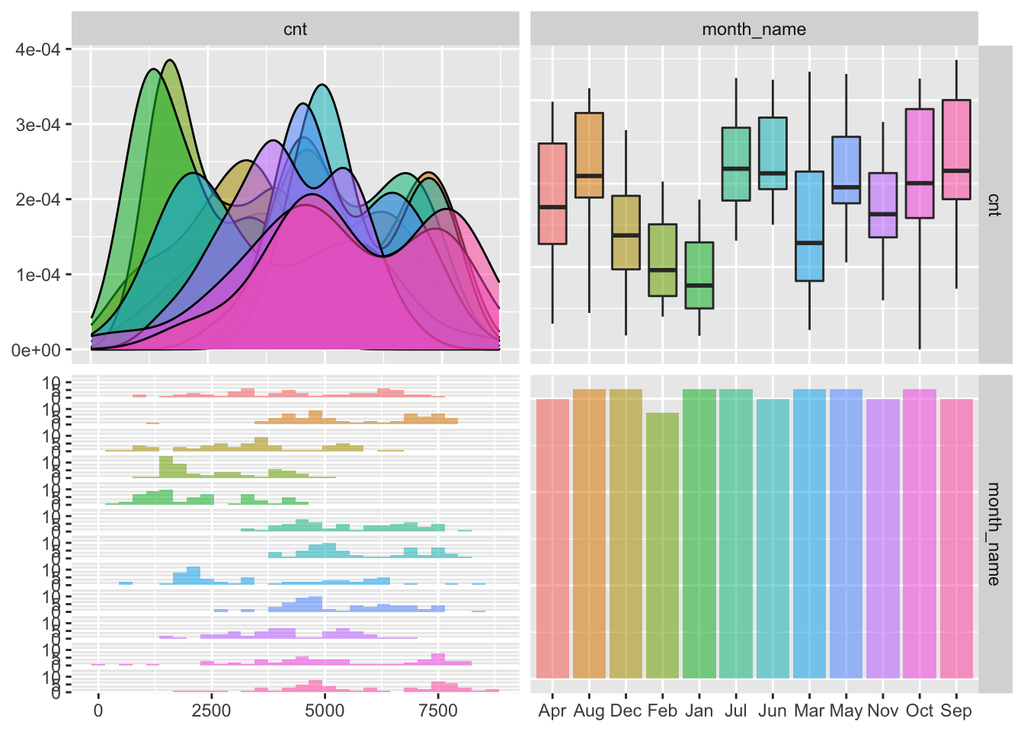

```r
ggpairs(df
        , columns = c(16,17) # Only include month_name and cnt
        , aes(color = month_name # Let's see if we can identify any difference among campaign.
              , alpha = .4 # Makes the colors partially transparent
              )
        )
```

# Predict which month set as reference and cnt (April is Reference)

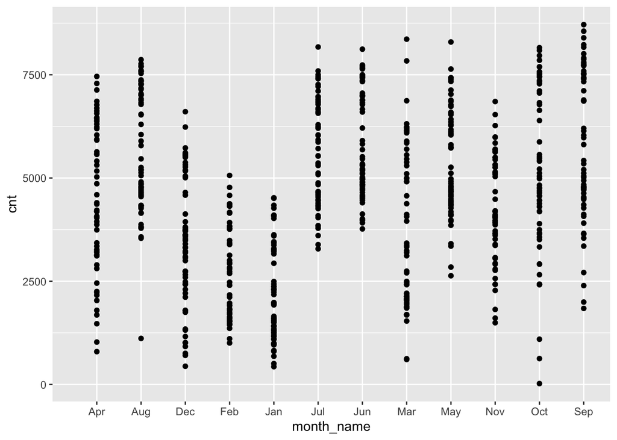

```r
ggplot(model1, aes(x = month_name, y = cnt)) +
  geom_point() +
  expand_limits(x = c(0,1)) +
  stat_smooth(method = 'lm', fullrange = T)
```

```r
newObservations <- data.frame(month_name = 'Apr'
                              , cnt = c(2000, 3000, 4000) )

newObservations$predictedCnt = predict(model1, newObservations)
```

As shown in the summary of Model1, April is set as the reference month. The predicted count for April would be, cnt = 4484.9

# Use Coefficients to estimate cnt for months of January and June

```r
cnt_Jan <- 4484.9 + -2308.6
cnt_Jan
```

```
## [1] 2176.3
```

```r
cnt_Jun <- 4484.9 + 1287.5
cnt_Jun
```

```
## [1] 5772.4
```

# Multiple Linear Regression cnt (dep) & temp/month_name (indep)

```r
model2 <- lm(cnt ~ temp + month_name, data = df)
```

# Summary of Model2

```r
summary(model2)
```

```
##
## Call:
## lm(formula = cnt ~ temp + month_name, data = df)
##
## Residuals:
##     Min      1Q  Median      3Q     Max
## -4896.6 -1080.0  -228.4  1245.2  3372.9
##
## Coefficients:
##               Estimate Std. Error t value Pr(>|t|)
## (Intercept)    1554.39     390.76   3.978 7.66e-05 ***
## temp           6235.14     729.40   8.548  < 2e-16 ***
## month_nameAug  -308.08     315.42  -0.977   0.3290
## month_nameDec  -170.96     283.80  -0.602   0.5471
## month_nameFeb  -764.81     296.15  -2.582   0.0100 *
## month_nameJan  -852.31     313.41  -2.719   0.0067 **
## month_nameJul  -701.18     335.50  -2.090   0.0370 *
## month_nameJun   -47.47     307.78  -0.154   0.8775
## month_nameMar  -297.20     269.38  -1.103   0.2703
## month_nameMay    86.73     278.37   0.312   0.7555
## month_nameNov   390.66     275.22   1.419   0.1562
## month_nameOct   620.72     263.30   2.357   0.0187 *
## month_nameSep   368.25     285.93   1.288   0.1982
## ---
## Signif. codes:  0 '***' 0.001 '**' 0.01 '*' 0.05 '.' 0.1 ' ' 1
##
## Residual standard error: 1453 on 718 degrees of freedom
## Multiple R-squared:  0.4469, Adjusted R-squared:  0.4377
## F-statistic: 48.35 on 12 and 718 DF,  p-value: < 2.2e-16
```

***Explain why the R-squared is different from the two simple regression models

Model2 is different from Model1 due to adding in the temp into the Linear Regression Model. Since temp has a higher coefficient meaning higher correlation, the R squared value is a little bit higher than the R squared in Model1.

***Compare the coefficient estimates for the month_nameJan variable in Model1 and Model2.

With regular text explain why the coefficient estimates are different. Model1 Jan Coefficient is -2308.6 while Model2 Jan coeff is -852.31. They are different because when adding in the Temp variable, the correlation increases which is shown by the increase in R squared causing a better correlation in Model2 Jan coeff.

***With either a code chunk or regular text, use the coefficient estimates from Model2 to report the predicted cnt for the month of January when the temperature is .25

```r
cnt_Jan_Temp = 1554.39 + -852.31 + 0.25 * 6235.14
cnt_Jan_Temp
```

```
## [1] 2260.865
```